# 6-이론 slides

## 결정트리

데이터의 규칙을 학습을 통해 찾아내 트리 기반의 분류 규칙 만드는 것

질문을 통해 데이터를 분류함(if/else)

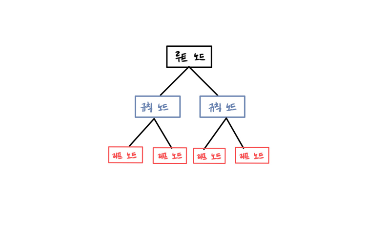

### 지니 불순도

잘못 분류된 데이터가 어느정도 포함되어 있는지 확인할 수 있는 지표

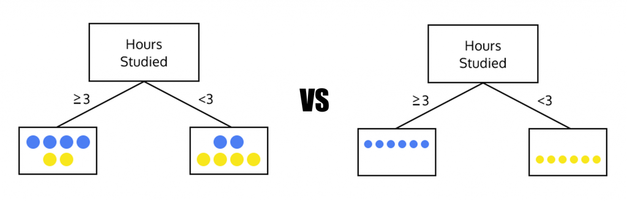

1-[(전체 데이터 개수 중 각 레이블이 차지하는 개수 비율)^2]

- 하나의 값으로만 구성되면 지니 불순도는 0
- 지니 불순도가 작을수록 균일도가 높음(잘 분류됨)

### 정보 이득

엔트로피 개념 기반

- 엔트로피  
  = 주어진 데이터 집합의 혼잡도

  -서로 다른 값이 섞여 있으면 엔트로피가 높아짐

정보 이득 지수 = 1- 엔트로피 지수  
∴정보 이득이 높은 속성을 이용함

결정트리를 만들 때 정보 획득량이 큰 순서대로 질문 배치하는 것이 좋음  
~> 속성에 대해 어느 기준으로 나누는게 좋을지 반복적으로 적용하며 최적 트리를 찾음 = "재귀 알고리즘"

### 결정트리 모델 특징

- 장점

쉽고 직관적

룰이 매우 명확, 노드 만들어지는 과정 알 수 있음

전처리 작업 필요 없음

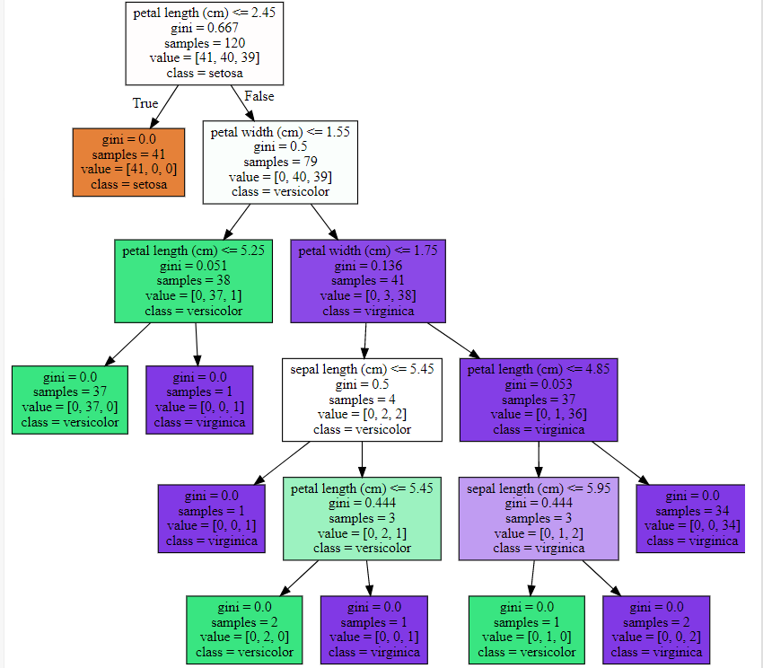

- 단점

과적합으로 인한 알고리즘 성능 저하

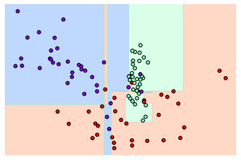

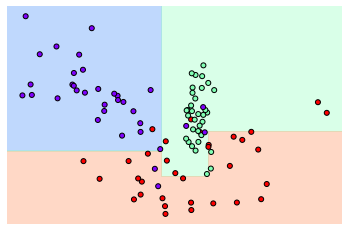